# ProjectPart2-Task-1

```python
import pandas as pd
import numpy as np
import matplotlib.pyplot as plt
import os
from sklearn.linear_model import LinearRegression
from sklearn.impute import SimpleImputer
from statsmodels.tsa.arima.model import ARIMA
from pmdarima import auto_arima
from statsmodels.tsa.stattools import coint
from statsmodels.tsa.stattools import adfuller



def load_concat_data(directory_path):
    all_data = []

    for filename in os.listdir(directory_path):
        if filename.endswith(".csv"):
            file_path = os.path.join(directory_path, filename)
            data = pd.read_csv(file_path, parse_dates=['timestamp'])

            # Convert 'price' column to numeric
            data['price'] = pd.to_numeric(data['price'], errors='coerce')

            all_data.append(data)

    if all_data:
        # Assuming each file has columns: 'timestamp', 'short_name', 'price', and potentially others
        concatenated_data = pd.concat(all_data, ignore_index=True)

        # Ensure 'timestamp' column is in datetime format
        concatenated_data['timestamp'] = pd.to_datetime(concatenated_data['timestamp'])

        return concatenated_data
    else:
        raise ValueError("No CSV files found in the specified directory.")


# Main script
# Example usage, replace 'path_to_data_directory' with the actual directory path
data_directory = r'C:\Users\zayt\Downloads\stockdata'  # Use 'r' before the string to handle backslashes
stock_data = load_concat_data(data_directory)

# Display the first few rows of the concatenated data for verification
print(stock_data.head())
```

```
                  timestamp  price short_name
0 2018-01-02 09:00:00+03:00  15.79      THYAO
1 2018-01-02 10:00:00+03:00  16.01      THYAO
2 2018-01-02 11:00:00+03:00  16.05      THYAO
3 2018-01-02 12:00:00+03:00  16.05      THYAO
4 2018-01-02 13:00:00+03:00  16.06      THYAO
```

Our stockdata file includes data between 2018-01 and 2019-12.

```python
# Pivot the data to wide format
wide_data = stock_data.pivot(index='timestamp', columns='short_name', values='price')

# Calculate correlations
correlations = wide_data.corr()

# Find highly correlated pairs
threshold = 0.89
highly_correlated_pairs = set()

for stock1 in correlations.columns:
    for stock2 in correlations.columns:
        if stock1 < stock2 and correlations.at[stock1, stock2] > threshold:
            correlation_value = correlations.at[stock1, stock2]
            pair = (stock1, stock2, correlation_value)
            highly_correlated_pairs.add(pair)

# Print highly correlated pairs
print("Highly Correlated Pairs:")
for pair in highly_correlated_pairs:
    print(f"{pair[0]} - {pair[1]} | Correlation: {pair[2]}")
```

```
Highly Correlated Pairs:
GARAN - SAHOL | Correlation: 0.8999415048451549
AKBNK - GARAN | Correlation: 0.9671397199754406
AKBNK - TTKOM | Correlation: 0.8918447144903245
GARAN - ISCTR | Correlation: 0.9018116538029088
AKBNK - SAHOL | Correlation: 0.9501556379158096
AKBNK - ISCTR | Correlation: 0.9045865559582479
ISCTR - SAHOL | Correlation: 0.9218135917518057
ISCTR - VAKBN | Correlation: 0.899751112990344
SAHOL - VAKBN | Correlation: 0.9133634143462116
AKBNK - VAKBN | Correlation: 0.8919154276020033
SAHOL - YKBNK | Correlation: 0.9218910077428514
ISCTR - YKBNK | Correlation: 0.9438751954899298
SAHOL - TTKOM | Correlation: 0.8953064396572138
VAKBN - YKBNK | Correlation: 0.8902153092652203
```

The script calculates correlations between stock pairs and identifies highly correlated pairs based on a specified threshold. The results are printed, showing the stock pairs that exhibit a correlation greater than the threshold. This analysis helps in selecting pairs for further investigation in the pairs trading strategy.

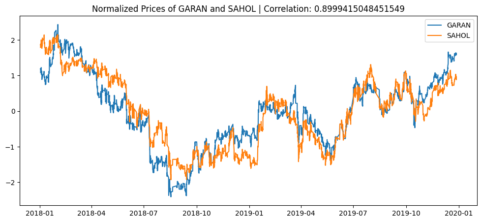

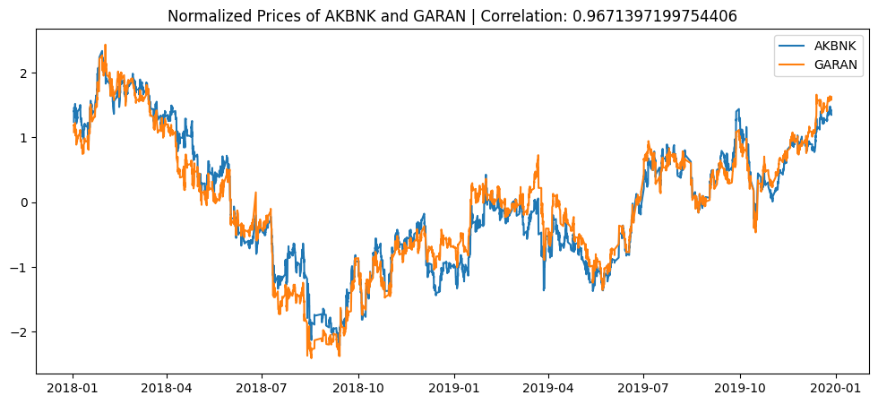

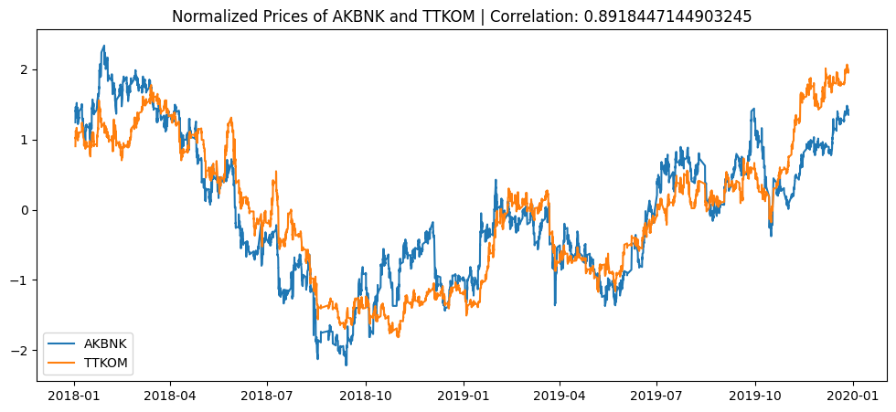

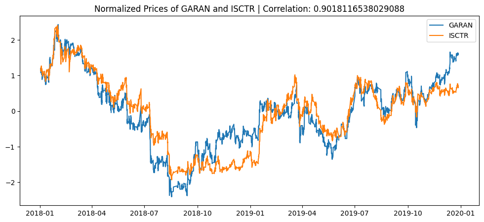

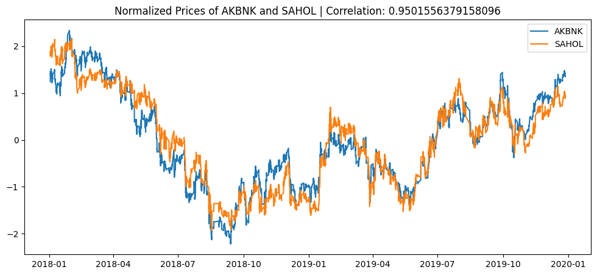

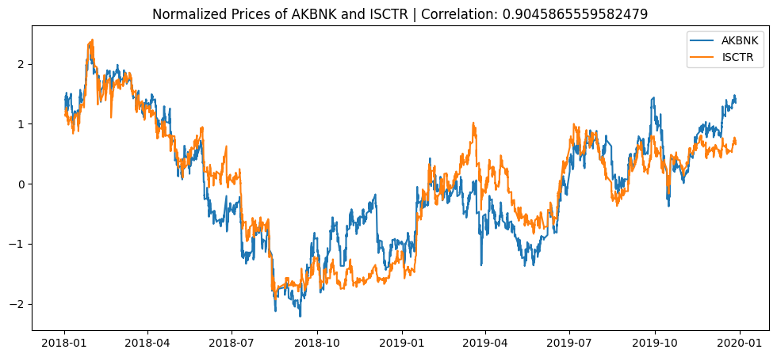

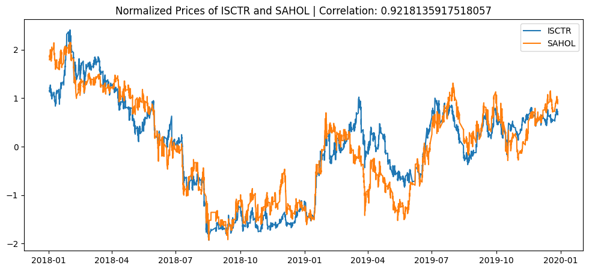

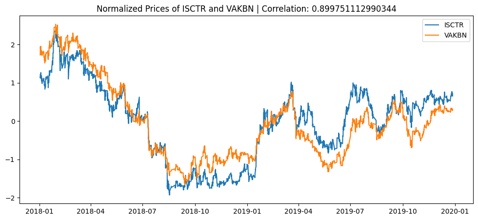

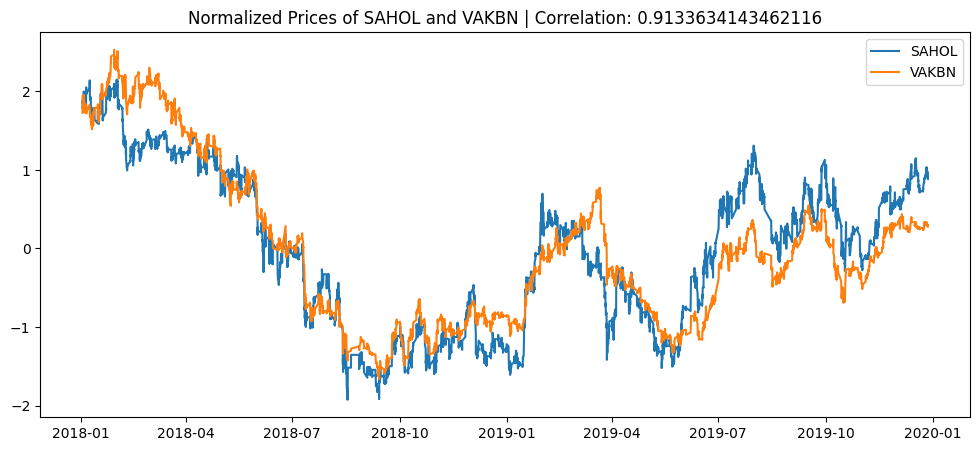

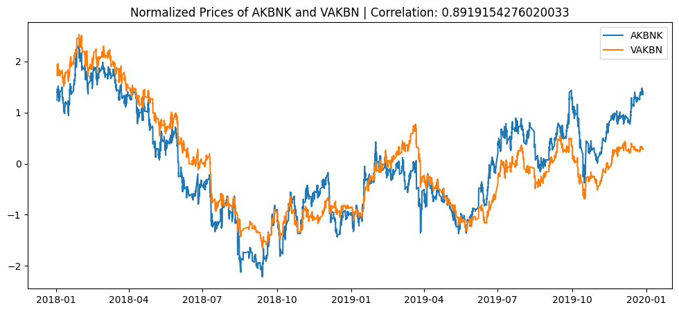

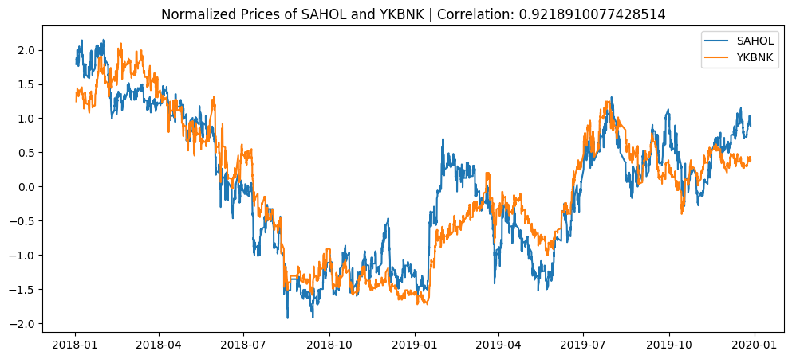

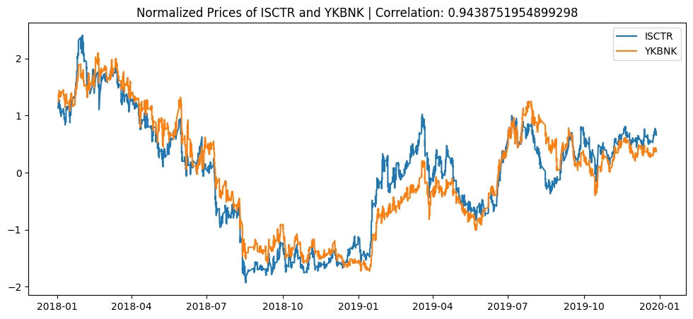

[2 more figures not shown]

```python
# Plot highly correlated pairs
for pair in highly_correlated_pairs:
    stock1, stock2, correlation_value = pair

    fig, ax = plt.subplots(figsize=(12, 5))
    ax.set_title(f"Normalized Prices of {stock1} and {stock2} | Correlation: {correlation_value}")

    normalized_stock_1 = (wide_data[stock1] - wide_data[stock1].mean()) / wide_data[stock1].std()
    normalized_stock_2 = (wide_data[stock2] - wide_data[stock2].mean()) / wide_data[stock2].std()

    ax.plot(wide_data.index, normalized_stock_1, label=stock1)
    ax.plot(wide_data.index, normalized_stock_2, label=stock2)
    ax.legend()

plt.show()
```

```
Intercept (alfa1): -0.06450065990485232
Slope (beta1): 0.28663103658010314
Residual Standard Deviation: 0.16401328808755175
```

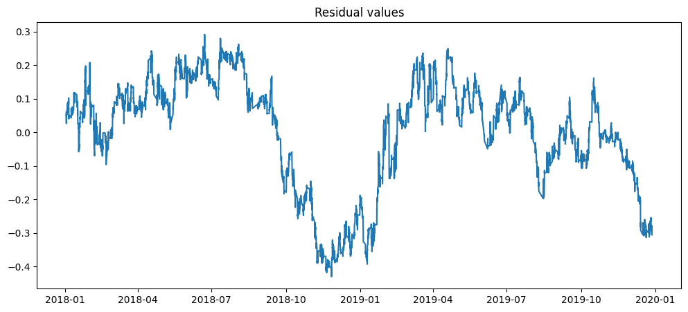

```python
# Assuming 'wide_data' is the DataFrame containing your wide-format data
# Replace this with your actual DataFrame if it's named differently

# Select relevant columns and make them 1-dimensional
ISCTR_prices = wide_data['ISCTR'].values
GARAN_prices = wide_data['GARAN'].values


# Create a linear regression model for GARAN with respect to ISCTR
model = LinearRegression().fit(GARAN_prices.reshape(-1, 1), ISCTR_prices)

# Display regression results
print(f"Intercept (alfa1): {model.intercept_}")
print(f"Slope (beta1): {model.coef_[0]}")

# Calculate residuals and residual standard deviation
residuals = ISCTR_prices - model.predict(GARAN_prices.reshape(-1, 1))
residual_std = np.std(residuals)
print(f"Residual Standard Deviation: {residual_std}")

# Plot residuals
plt.figure(figsize=(12, 5))
plt.plot(wide_data.index, residuals)
plt.title("Residual values")
plt.show()
```

Two stock pairs, namely ISCTR-GARAN and ISCTR-YKBNK, are selected for analysis. The code calculates a linear regression model for the relationship between GARAN and ISCTR stock prices. The regression results, including the intercept and slope, are displayed. The residuals and their standard deviation are then computed, providing insights into the deviations from the linear relationship. Finally, a plot of the residuals over time is generated for visual analysis. This step is crucial for understanding the historical relationship between the selected stock pairs and will be further utilized in the pairs trading strategy.

```
Intercept (alfa1): 0.31389621895738284
Slope (beta1): 0.9537157194923274
Residual Standard Deviation: 0.12536517759204993
```

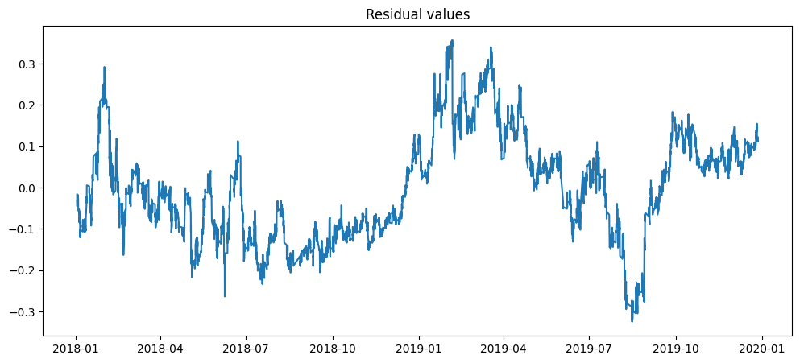

```python
# Assuming 'wide_data' is the DataFrame containing your wide-format data
# Replace this with your actual DataFrame if it's named differently

# Select relevant columns and make them 1-dimensional
ISCTR_prices = wide_data['ISCTR'].values
YKBNK_prices = wide_data['YKBNK'].values


# Create a linear regression model for YKBNK with respect to ISCTR
model = LinearRegression().fit(YKBNK_prices.reshape(-1, 1), ISCTR_prices)

# Display regression results
print(f"Intercept (alfa1): {model.intercept_}")
print(f"Slope (beta1): {model.coef_[0]}")

# Calculate residuals and residual standard deviation
residuals = ISCTR_prices - model.predict(YKBNK_prices.reshape(-1, 1))
residual_std = np.std(residuals)
print(f"Residual Standard Deviation: {residual_std}")

# Plot residuals
plt.figure(figsize=(12, 5))
plt.plot(wide_data.index, residuals)
plt.title("Residual values")
plt.show()
```

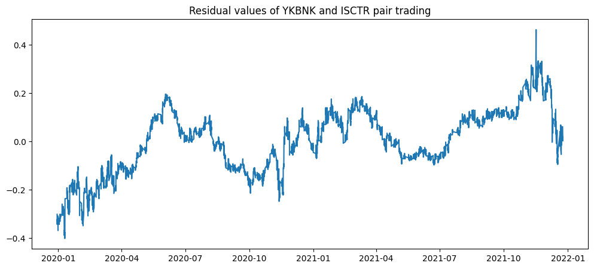

[output not shown]

[output cut: 4895 more lines]

[output not shown]

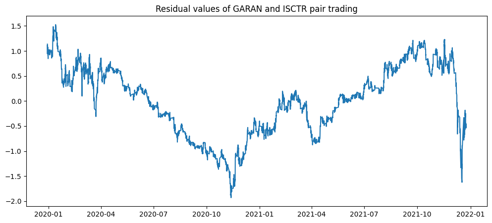

[output not shown]

[output cut: 4907 more lines]

```
Sell: 0.21399784120962514 shares at 10.61
Sell: 0.21399784120962514 shares at 10.6372
Sell: 0.21399784120962514 shares at 10.6645
ISCTR-YKBNK pair trading:
Starting money: 1
Final money: 1.73
Profit: %73.10
Shares bought: 0.00
Shares sold: 0.00
ISCTR-GARAN pair trading:
Starting money: 1
Final money: 2.28
Profit: %128.22
Shares bought: 0.00
Shares sold: 0.21
```

```python
def pairs_trading_simulation(long_data, independent_stock, dependent_stock, money=1, upper_limit=1, lower_limit=-1, max_shares=1e6):
    """
    Perform pairs trading simulation for given stock pairs.

    Parameters:
    - long_data: Pandas DataFrame, long-format data
    - independent_stock: str, the name of the independent variable stock
    - dependent_stock: str, the name of the dependent variable stock
    - money: float, initial capital
    - upper_limit: float, upper control limit for residual
    - lower_limit: float, lower control limit for residual
    - max_shares: float, maximum number of shares to buy or sell in a single transaction

    Returns:
    - final_money: float, final capital after simulation
    - shares_bought: float, shares bought during the simulation
    - shares_sold: float, shares sold during the simulation
    - profit: float, profit percentage
    """
    # Filter data for the specific stocks
    stock_data = long_data[long_data['short_name'].isin([independent_stock, dependent_stock])]

    # Pivot the data to wide format
    stock_prices = stock_data.pivot(index='timestamp', columns='short_name', values='price')

    # Impute missing values
    imputer = SimpleImputer(strategy='mean')
    stock_prices_imputed = pd.DataFrame(imputer.fit_transform(stock_prices), columns=stock_prices.columns, index=stock_prices.index)

    # Create a linear regression model
    model = LinearRegression().fit(stock_prices_imputed[independent_stock].values.reshape(-1, 1),
                                   stock_prices_imputed[dependent_stock].values)

    # Calculate residuals and residual standard deviation
    residuals = stock_prices_imputed[dependent_stock] - model.predict(stock_prices_imputed[independent_stock].values.reshape(-1, 1))
    residual_std = np.std(residuals)

    # Plot residuals
    plt.figure(figsize=(12, 5))
    plt.plot(stock_prices_imputed.index, residuals)
    plt.title(f"Residual values of {dependent_stock} and {independent_stock} pair trading")
    plt.show()

    # Simulation
    shares_bought = 0
    shares_sold = 0

    for i in range(len(residuals)):
        if residuals.iloc[i] > 0:
            if shares_sold > 0:
                money += min(shares_sold * stock_prices_imputed[dependent_stock].iloc[i], max_shares)
                shares_sold = 0
            if money > 0 and residuals.iloc[i] > upper_limit * residual_std:
                shares_bought = min(money / stock_prices_imputed[independent_stock].iloc[i], max_shares)
                money = 0
            print(f"Buy: {shares_bought} shares at {stock_prices_imputed[independent_stock].iloc[i]}")

        elif residuals.iloc[i] < 0:
            if shares_bought > 0:
                money += min(shares_bought * stock_prices_imputed[independent_stock].iloc[i], max_shares)
                shares_bought = 0
            if money > 0 and residuals.iloc[i] < lower_limit * residual_std:
                shares_sold = min(money / stock_prices_imputed[dependent_stock].iloc[i], max_shares)
                money = 0
            print(f"Sell: {shares_sold} shares at {stock_prices_imputed[dependent_stock].iloc[i]}")

    # Calculate final money and profit
    final_money = money + shares_bought * stock_prices_imputed[independent_stock].iloc[-1] + shares_sold * stock_prices_imputed[dependent_stock].iloc[-1]
    profit = (final_money - 1) * 100

    return final_money, shares_bought, shares_sold, profit

# Replace this with the actual directory where your data is stored
test_directory = r'C:\Users\zayt\Downloads\testdata'
test_data = load_concat_data(test_directory)

# Perform pairs trading simulation for ISCTR-YKBNK pair
final_money_ykbnk, shares_bought_ykbnk, shares_sold_ykbnk, profit_ykbnk = pairs_trading_simulation(test_data, 'ISCTR', 'YKBNK')

# Perform pairs trading simulation for ISCTR-GARAN pair
final_money_garan, shares_bought_garan, shares_sold_garan, profit_garan = pairs_trading_simulation(test_data, 'ISCTR', 'GARAN')

# Display results
print(f"ISCTR-YKBNK pair trading:\nStarting money: 1\nFinal money: {final_money_ykbnk:.2f}\n"
      f"Profit: %{profit_ykbnk:.2f}\nShares bought: {shares_bought_ykbnk:.2f}\nShares sold: {shares_sold_ykbnk:.2f}")

print(f"ISCTR-GARAN pair trading:\nStarting money: 1\nFinal money: {final_money_garan:.2f}\n"
      f"Profit: %{profit_garan:.2f}\nShares bought: {shares_bought_garan:.2f}\nShares sold: {shares_sold_garan:.2f}")
```

The data taken is between 2020-01 and 2021-12 as test_data. This script performs a pairs trading simulation for two selected stock pairs: ISCTR-YKBNK and ISCTR-GARAN. It utilizes linear regression modeling, residual analysis, and control limits to make trading decisions based on historical data. The results, including final capital, profit percentage, and transaction details, are then displayed for both pairs.